# Mini-project

# Problem 1.6 : Latent Semantic Analysis (mandatory)

Each group uses the Latent Semantic Analysis method and the learned lessons to seek similar documents from the text dataset to the provided queries. The field-specific dataset is provided by the Instructor. The solution must include text data pre-processing, term-document matrix generation, and singular value decomposition application.

# 1. Import the libraries and the dataset

# A. Import the libraries

```python
import numpy as np
import pandas as pd
import matplotlib.pyplot as plt
import seaborn as sns
pd.set_option("display.max_colwidth", 200)
```

# B. Import the dataset

```python
dataset=pd.read_csv('/Users/nguyenphankhanhlinh/Downloads/datafiles/group10.csv')
dataset.head(3)
```

|  | 90443 | 416911 | mozilla | alice nodelman [:alice] [:anode] | alice nodelman [:alice] [:anode].1 | 2008-02-11 16:24:00 | 2009-05-18 10:44:00 | 2009-05-18 10:44:00.1 | feature | fixed | per-test timeout in talos | Release Engineer | mozilla.org | Unnamed: 13 | all | 386081 | talo hour time limit test pretti major delai browser freez correctli report failur pretti code start made buildbot talo config file updat timeout test creat attach detail diff review test timeout talo… |
| --- | --- | --- | --- | --- | --- | --- | --- | --- | --- | --- | --- | --- | --- | --- | --- | --- | --- |
| 0 | 90444 | 416912 | mozilla | Martijn Wargers [:mw22] (QA - IRC nick: | Nobody; OK to take it and work on it | 2008-02-11 16:45:00 | 2009-07-22 15:51:00 | 2009-07-22 15:51:00 | critical | fixed | Hang with message event and postMessage | Event Handling | Core | NaN | win | 197052 479430 391399 | creat attach detail testcas testcas hang trunk build load recurs call postmessag messag event lame mozilla shouldn hang show slow script warn relat bug guess js recurs error doesn stop recurs even... |
| 1 | 90445 | 416913 | mozilla | Pascal Chevrel:pascalc | chizu | 2008-02-11 16:51:00 | 2010-05-09 14:54:00 | 2010-05-09 14:54:00 | feature | fixed | Create localizer LDAP/SVN account for H\E5vard Mork | Repository Accou | mozilla.org | NaN | all | 252983 | creat svn account vard mork local nb-no nn-no email havard mork gmail ssh kei http bugzilla mozilla org/show_bug cgi id user subvers priv set quot projects/mozilla com/trunk/ local quot quot proje... |
| 2 | 90446 | 416914 | mozilla | Jesse Ruderman | Nobody; OK to take it and work on it | 2008-02-11 16:58:00 | 2010-02-24 22:43:00 | 2010-02-24 22:43:00 | feature | open | [BC] border-collapse makes table border width incorrect/inconsistent | Layout: Tables | Core | NaN | all | 381564 | creat attach detail testcas border testcas px bottom edg border-collaps tabl px wide mac window linux problem testcas zoom level window mozilla/5 window window nt en-u rv pre gecko/2008061305 mine... |

```python
dataset.columns = ['1','2','3','4','Detail','6','7','8','9','10','11','12','13','14','15','16','Description']
dataset.head(3)
```

|  | 1 | 2 | 3 | 4 | Detail | 6 | 7 | 8 | 9 | 10 | 11 | 12 | 13 | 14 | 15 | 16 | Description |
| --- | --- | --- | --- | --- | --- | --- | --- | --- | --- | --- | --- | --- | --- | --- | --- | --- | --- |
| 0 | 90444 | 416912 | mozilla | Martijn Wargers [:mw22] (QA - IRC nick: | Nobody; OK to take it and work on it | 2008-02-11 16:45:00 | 2009-07-22 15:51:00 | 2009-07-22 15:51:00 | critical | fixed | Hang with message event and postMessage | Event Handling | Core | NaN | win | 197052 479430 391399 | creat attach detail testcas testcas hang trunk build load recurs call postmessag messag event lame mozilla shouldn hang show slow script warn relat bug guess js recurs error doesn stop recurs even... |
| 1 | 90445 | 416913 | mozilla | Pascal Chevrel:pascalc | chizu | 2008-02-11 16:51:00 | 2010-05-09 14:54:00 | 2010-05-09 14:54:00 | feature | fixed | Create localizer LDAP/SVN account for H\E5vard Mork | Repository Accou | mozilla.org | NaN | all | 252983 | creat svn account vard mork local nb-no nn-no email havard mork gmail ssh kei http bugzilla mozilla org/show_bug cgi id user subvers priv set quot projects/mozilla com/trunk/ local quot quot proje... |
| 2 | 90446 | 416914 | mozilla | Jesse Ruderman | Nobody; OK to take it and work on it | 2008-02-11 16:58:00 | 2010-02-24 22:43:00 | 2010-02-24 22:43:00 | feature | open | [BC] border-collapse makes table border width incorrect/inconsistent | Layout: Tables | Core | NaN | all | 381564 | creat attach detail testcas border testcas px bottom edg border-collaps tabl px wide mac window linux problem testcas zoom level window mozilla/5 window window nt en-u rv pre gecko/2008061305 mine... |

```python
dataset=dataset[['Detail','Description']]
dataset.head()
```

|  | Detail | Description |
| --- | --- | --- |
| 0 | Nobody; OK to take it and work on it | creat attach detail testcas testcas hang trunk build load recurs call postmessag messag event lame mozilla shouldn hang show slow script warn relat bug guess js recurs error doesn stop recurs even... |
| 1 | chizu | creat svn account vard mork local nb-no nn-no email havard mork gmail ssh kei http bugzilla mozilla org/show_bug cgi id user subvers priv set quot projects/mozilla com/trunk/ local quot quot proje... |
| 2 | Nobody; OK to take it and work on it | creat attach detail testcas border testcas px bottom edg border-collaps tabl px wide mac window linux problem testcas zoom level window mozilla/5 window window nt en-u rv pre gecko/2008061305 mine... |
| 3 | Nobody; OK to take it and work on it | user-ag mozilla/5 x11 linux x86_64 en-u rv b4pre gecko/2008021122 firefox/3 b4pre build identifi constructor gfxfontstyl gfx/thebes/src/gfxfont cpp receiv languag group string argument string empt... |
| 4 | Nobody; OK to take it and work on it | nscxpusher push return pr_true bunch situat push fact time return pr_fals push push document scriptglobalobject fix return pr_true successfulli push context |

```python
dataset.shape
```

```
(10399, 2)
```

# 2. Data Preprocessing

```python
preprocessing_dataset= dataset
preprocessing_dataset.iloc[:5]
```

|  | Detail | Description |
| --- | --- | --- |
| 0 | Nobody; OK to take it and work on it | creat attach detail testcas testcas hang trunk build load recurs call postmessag messag event lame mozilla shouldn hang show slow script warn relat bug guess js recurs error doesn stop recurs even... |
| 1 | chizu | creat svn account vard mork local nb-no nn-no email havard mork gmail ssh kei http bugzilla mozilla org/show_bug cgi id user subvers priv set quot projects/mozilla com/trunk/ local quot quot proje... |
| 2 | Nobody; OK to take it and work on it | creat attach detail testcas border testcas px bottom edg border-collaps tabl px wide mac window linux problem testcas zoom level window mozilla/5 window window nt en-u rv pre gecko/2008061305 mine... |
| 3 | Nobody; OK to take it and work on it | user-ag mozilla/5 x11 linux x86_64 en-u rv b4pre gecko/2008021122 firefox/3 b4pre build identifi constructor gfxfontstyl gfx/thebes/src/gfxfont cpp receiv languag group string argument string empt... |
| 4 | Nobody; OK to take it and work on it | nscxpusher push return pr_true bunch situat push fact time return pr_fals push push document scriptglobalobject fix return pr_true successfulli push context |

# A. Lower-casting ( Make all text lowercase )

```python
preprocessing_dataset['Clean_First'] = preprocessing_dataset['Description'].apply(lambda x: x.lower())
preprocessing_dataset[['Description','Clean_First']].iloc[:5]
```

|  | Description | Clean_First |
| --- | --- | --- |
| 0 | creat attach detail testcas testcas hang trunk build load recurs call postmessag messag event lame mozilla shouldn hang show slow script warn relat bug guess js recurs error doesn stop recurs even... | creat attach detail testcas testcas hang trunk build load recurs call postmessag messag event lame mozilla shouldn hang show slow script warn relat bug guess js recurs error doesn stop recurs even... |
| 1 | creat svn account vard mork local nb-no nn-no email havard mork gmail ssh kei http bugzilla mozilla org/show_bug cgi id user subvers priv set quot projects/mozilla com/trunk/ local quot quot proje... | creat svn account vard mork local nb-no nn-no email havard mork gmail ssh kei http bugzilla mozilla org/show_bug cgi id user subvers priv set quot projects/mozilla com/trunk/ local quot quot proje... |
| 2 | creat attach detail testcas border testcas px bottom edg border-collaps tabl px wide mac window linux problem testcas zoom level window mozilla/5 window window nt en-u rv pre gecko/2008061305 mine... | creat attach detail testcas border testcas px bottom edg border-collaps tabl px wide mac window linux problem testcas zoom level window mozilla/5 window window nt en-u rv pre gecko/2008061305 mine... |
| 3 | user-ag mozilla/5 x11 linux x86_64 en-u rv b4pre gecko/2008021122 firefox/3 b4pre build identifi constructor gfxfontstyl gfx/thebes/src/gfxfont cpp receiv languag group string argument string empt... | user-ag mozilla/5 x11 linux x86_64 en-u rv b4pre gecko/2008021122 firefox/3 b4pre build identifi constructor gfxfontstyl gfx/thebes/src/gfxfont cpp receiv languag group string argument string empt... |
| 4 | nscxpusher push return pr_true bunch situat push fact time return pr_fals push push document scriptglobalobject fix return pr_true successfulli push context | nscxpusher push return pr_true bunch situat push fact time return pr_fals push push document scriptglobalobject fix return pr_true successfulli push context |

# B. Removing everything except alphabets ( Removal of punctuation )

```python
preprocessing_dataset['Clean_Second'] = preprocessing_dataset['Clean_First'].str.replace("[^a-zA-Z#]", " ")
preprocessing_dataset[['Clean_First','Clean_Second']].iloc[:5]
```

|  | Clean_First | Clean_Second |
| --- | --- | --- |
| 0 | creat attach detail testcas testcas hang trunk build load recurs call postmessag messag event lame mozilla shouldn hang show slow script warn relat bug guess js recurs error doesn stop recurs even... | creat attach detail testcas testcas hang trunk build load recurs call postmessag messag event lame mozilla shouldn hang show slow script warn relat bug guess js recurs error doesn stop recurs even... |
| 1 | creat svn account vard mork local nb-no nn-no email havard mork gmail ssh kei http bugzilla mozilla org/show_bug cgi id user subvers priv set quot projects/mozilla com/trunk/ local quot quot proje... | creat svn account vard mork local nb no nn no email havard mork gmail ssh kei http bugzilla mozilla org show bug cgi id user subvers priv set quot projects mozilla com trunk local quot quot proje... |
| 2 | creat attach detail testcas border testcas px bottom edg border-collaps tabl px wide mac window linux problem testcas zoom level window mozilla/5 window window nt en-u rv pre gecko/2008061305 mine... | creat attach detail testcas border testcas px bottom edg border collaps tabl px wide mac window linux problem testcas zoom level window mozilla window window nt en u rv pre gecko mine... |
| 3 | user-ag mozilla/5 x11 linux x86_64 en-u rv b4pre gecko/2008021122 firefox/3 b4pre build identifi constructor gfxfontstyl gfx/thebes/src/gfxfont cpp receiv languag group string argument string empt... | user ag mozilla x linux x en u rv b pre gecko firefox b pre build identifi constructor gfxfontstyl gfx thebes src gfxfont cpp receiv languag group string argument string empt... |
| 4 | nscxpusher push return pr_true bunch situat push fact time return pr_fals push push document scriptglobalobject fix return pr_true successfulli push context | nscxpusher push return pr true bunch situat push fact time return pr fals push push document scriptglobalobject fix return pr true successfulli push context |

# C. Removing short words ( Remove words with length less than or equal to 3 )

```python
preprocessing_dataset['Clean_Third'] = preprocessing_dataset['Clean_Second'].apply(lambda x: ' '.join([w for w in x.split() if len(w)>3]))
preprocessing_dataset[['Clean_Second','Clean_Third']].iloc[:5]
```

|  | Clean_Second | Clean_Third |
| --- | --- | --- |
| 0 | creat attach detail testcas testcas hang trunk build load recurs call postmessag messag event lame mozilla shouldn hang show slow script warn relat bug guess js recurs error doesn stop recurs even... | creat attach detail testcas testcas hang trunk build load recurs call postmessag messag event lame mozilla shouldn hang show slow script warn relat guess recurs error doesn stop recurs event handl... |
| 1 | creat svn account vard mork local nb no nn no email havard mork gmail ssh kei http bugzilla mozilla org show bug cgi id user subvers priv set quot projects mozilla com trunk local quot quot proje... | creat account vard mork local email havard mork gmail http bugzilla mozilla show user subvers priv quot projects mozilla trunk local quot quot projects mozilla europ trunk local quot quot projects... |
| 2 | creat attach detail testcas border testcas px bottom edg border collaps tabl px wide mac window linux problem testcas zoom level window mozilla window window nt en u rv pre gecko mine... | creat attach detail testcas border testcas bottom border collaps tabl wide window linux problem testcas zoom level window mozilla window window gecko minefield zoom level linux mozilla linux gecko... |
| 3 | user ag mozilla x linux x en u rv b pre gecko firefox b pre build identifi constructor gfxfontstyl gfx thebes src gfxfont cpp receiv languag group string argument string empt... | user mozilla linux gecko firefox build identifi constructor gfxfontstyl thebes gfxfont receiv languag group string argument string empti emit warn line languag group quot western quot nssystemfont... |
| 4 | nscxpusher push return pr true bunch situat push fact time return pr fals push push document scriptglobalobject fix return pr true successfulli push context | nscxpusher push return true bunch situat push fact time return fals push push document scriptglobalobject return true successfulli push context |

# D. Remove stop-words

```python
# We must import NLTK to remove the stopword
import nltk
nltk.download('stopwords')

from nltk.corpus import stopwords
", ".join(stopwords.words('english'))
STOPW = set(stopwords.words('english'))
def remove_stopwords(text):
    return " ".join([word for word in str(text).split() if word not in STOPW])
```

```python
preprocessing_dataset["Clean_Fourth"] = preprocessing_dataset["Clean_Third"].apply(lambda text: remove_stopwords(text))
preprocessing_dataset[['Clean_Third','Clean_Fourth']].iloc[:5]
```

|  | Clean_Third | Clean_Fourth |
| --- | --- | --- |
| 0 | creat attach detail testcas testcas hang trunk build load recurs call postmessag messag event lame mozilla shouldn hang show slow script warn relat guess recurs error doesn stop recurs event handl... | creat attach detail testcas testcas hang trunk build load recurs call postmessag messag event lame mozilla hang show slow script warn relat guess recurs error stop recurs event handler post messag... |
| 1 | creat account vard mork local email havard mork gmail http bugzilla mozilla show user subvers priv quot projects mozilla trunk local quot quot projects mozilla europ trunk local quot quot projects... | creat account vard mork local email havard mork gmail http bugzilla mozilla show user subvers priv quot projects mozilla trunk local quot quot projects mozilla europ trunk local quot quot projects... |
| 2 | creat attach detail testcas border testcas bottom border collaps tabl wide window linux problem testcas zoom level window mozilla window window gecko minefield zoom level linux mozilla linux gecko... | creat attach detail testcas border testcas bottom border collaps tabl wide window linux problem testcas zoom level window mozilla window window gecko minefield zoom level linux mozilla linux gecko... |
| 3 | user mozilla linux gecko firefox build identifi constructor gfxfontstyl thebes gfxfont receiv languag group string argument string empti emit warn line languag group quot western quot nssystemfont... | user mozilla linux gecko firefox build identifi constructor gfxfontstyl thebes gfxfont receiv languag group string argument string empti emit warn line languag group quot western quot nssystemfont... |
| 4 | nscxpusher push return true bunch situat push fact time return fals push push document scriptglobalobject return true successfulli push context | nscxpusher push return true bunch situat push fact time return fals push push document scriptglobalobject return true successfulli push context |

# E. Steming

```python
from nltk.stem.porter import PorterStemmer
stemmer = PorterStemmer()
def stem_words(text):
    return " ".join([stemmer.stem(word) for word in text.split()])
```

```python
preprocessing_dataset["Clean_Fifth"]=preprocessing_dataset["Clean_Fourth"].apply(lambda text: stem_words(text))
preprocessing_dataset[['Clean_Fourth','Clean_Fifth']].iloc[:5]
```

|  | Clean_Fourth | Clean_Fifth |
| --- | --- | --- |
| 0 | creat attach detail testcas testcas hang trunk build load recurs call postmessag messag event lame mozilla hang show slow script warn relat guess recurs error stop recurs event handler post messag... | creat attach detail testca testca hang trunk build load recur call postmessag messag event lame mozilla hang show slow script warn relat guess recur error stop recur event handler post messag simi... |
| 1 | creat account vard mork local email havard mork gmail http bugzilla mozilla show user subvers priv quot projects mozilla trunk local quot quot projects mozilla europ trunk local quot quot projects... | creat account vard mork local email havard mork gmail http bugzilla mozilla show user subver priv quot project mozilla trunk local quot quot project mozilla europ trunk local quot quot project goo... |
| 2 | creat attach detail testcas border testcas bottom border collaps tabl wide window linux problem testcas zoom level window mozilla window window gecko minefield zoom level linux mozilla linux gecko... | creat attach detail testca border testca bottom border collap tabl wide window linux problem testca zoom level window mozilla window window gecko minefield zoom level linux mozilla linux gecko min... |
| 3 | user mozilla linux gecko firefox build identifi constructor gfxfontstyl thebes gfxfont receiv languag group string argument string empti emit warn line languag group quot western quot nssystemfont... | user mozilla linux gecko firefox build identifi constructor gfxfontstyl thebe gfxfont receiv languag group string argument string empti emit warn line languag group quot western quot nssystemfonts... |
| 4 | nscxpusher push return true bunch situat push fact time return fals push push document scriptglobalobject return true successfulli push context | nscxpusher push return true bunch situat push fact time return fal push push document scriptglobalobject return true success push context |

# F. Comparison between initial description and clean_description

```python
preprocessing_dataset[['Description','Clean_Fifth']].iloc[:5]
```

|  | Description | Clean_Fifth |
| --- | --- | --- |
| 0 | creat attach detail testcas testcas hang trunk build load recurs call postmessag messag event lame mozilla shouldn hang show slow script warn relat bug guess js recurs error doesn stop recurs even... | creat attach detail testca testca hang trunk build load recur call postmessag messag event lame mozilla hang show slow script warn relat guess recur error stop recur event handler post messag simi... |
| 1 | creat svn account vard mork local nb-no nn-no email havard mork gmail ssh kei http bugzilla mozilla org/show_bug cgi id user subvers priv set quot projects/mozilla com/trunk/ local quot quot proje... | creat account vard mork local email havard mork gmail http bugzilla mozilla show user subver priv quot project mozilla trunk local quot quot project mozilla europ trunk local quot quot project goo... |
| 2 | creat attach detail testcas border testcas px bottom edg border-collaps tabl px wide mac window linux problem testcas zoom level window mozilla/5 window window nt en-u rv pre gecko/2008061305 mine... | creat attach detail testca border testca bottom border collap tabl wide window linux problem testca zoom level window mozilla window window gecko minefield zoom level linux mozilla linux gecko min... |
| 3 | user-ag mozilla/5 x11 linux x86_64 en-u rv b4pre gecko/2008021122 firefox/3 b4pre build identifi constructor gfxfontstyl gfx/thebes/src/gfxfont cpp receiv languag group string argument string empt... | user mozilla linux gecko firefox build identifi constructor gfxfontstyl thebe gfxfont receiv languag group string argument string empti emit warn line languag group quot western quot nssystemfonts... |
| 4 | nscxpusher push return pr_true bunch situat push fact time return pr_fals push push document scriptglobalobject fix return pr_true successfulli push context | nscxpusher push return true bunch situat push fact time return fal push push document scriptglobalobject return true success push context |

# 3. Document Term matrix

```python
from sklearn.feature_extraction.text import TfidfVectorizer
```

```python
vectorizer = TfidfVectorizer(stop_words='english', max_features= 2000, max_df = 0.5, smooth_idf=True)
```

```python
doc_term_matrix= vectorizer.fit_transform(preprocessing_dataset['Clean_Fifth'])
```

```python
doc_term_matrix.shape
```

```
(10399, 2000)
```

# 4. FIND OPTIMAL TOPICS USING EXPLAINED VARIANCE RATIO

```python
from sklearn.decomposition import TruncatedSVD
```

```python
# Program to find the optimal number of components for Truncated SVD
n_comp = [5,15,30, 60, 90, 180, 250,350,500,800,1000] # list containing different values of components
explained = [] # explained variance ratio for each component of Truncated SVD
for x in n_comp:
    svd = TruncatedSVD(n_components=x, algorithm='randomized', n_iter=100)
    svd.fit(doc_term_matrix)
    explained.append(svd.explained_variance_ratio_.sum())
    print("Number of components = %r and explained variance = %r"%(x,svd.explained_variance_ratio_.sum()))
```

```
Number of components = 5 and explained variance = 0.06677507610294882
Number of components = 15 and explained variance = 0.13551072672543416
Number of components = 30 and explained variance = 0.2013576679853172
Number of components = 60 and explained variance = 0.29044836486954567
Number of components = 90 and explained variance = 0.3556940736543207
Number of components = 180 and explained variance = 0.4906564367908294
Number of components = 250 and explained variance = 0.5646180060589657
Number of components = 350 and explained variance = 0.6443122924404197
Number of components = 500 and explained variance = 0.7325908867135695
Number of components = 800 and explained variance = 0.8478193421059983
Number of components = 1000 and explained variance = 0.8980323747676178
```

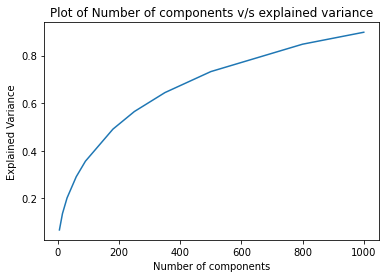

```python
plt.plot(n_comp, explained)
plt.xlabel('Number of components')
plt.ylabel("Explained Variance")
plt.title("Plot of Number of components v/s explained variance")
plt.show()
```

# 5. SINGULAR-VALUE-DECOMPOSITION (SVD)

```python
# SVD represent documents and terms in vectors
svd_model = TruncatedSVD(n_components=800, algorithm='randomized', n_iter=100, random_state=122)
svd_model.fit(doc_term_matrix)
```

```
TruncatedSVD(n_components=800, n_iter=100, random_state=122)
```

```python
# print out some some topics of SVD model

terms = vectorizer.get_feature_names()

for i, comp in enumerate(svd_model.components_):
    terms_comp = zip(terms, comp)
    sorted_terms = sorted(terms_comp, key= lambda x:x[1], reverse=True)[:7]
    terms=[]
    for t in sorted_terms:
        terms.append(t[0])
    print("Topic "+str(i)+": ",terms)
```

```
Topic 0:  ['attach', 'review', 'diff', 'comment', 'patch', 'bookmark', 'page']
Topic 1:  ['diff', 'bookmark', 'attach', 'patch', 'comment', 'review', 'page']
Topic 2:  ['bookmark', 'patch', 'diff', 'review', 'attach', 'comment', 'page']
Topic 3:  ['bookmark', 'attach', 'comment', 'review', 'patch', 'diff', 'page']
Topic 4:  ['review', 'attach', 'diff', 'bookmark', 'page', 'comment', 'patch']
Topic 5:  ['bookmark', 'review', 'comment', 'diff', 'attach', 'page', 'patch']
Topic 6:  ['review', 'page', 'bookmark', 'attach', 'diff', 'comment', 'patch']
Topic 7:  ['bookmark', 'attach', 'review', 'comment', 'page', 'patch', 'diff']
Topic 8:  ['comment', 'page', 'review', 'patch', 'bookmark', 'attach', 'diff']
Topic 9:  ['review', 'attach', 'comment', 'page', 'diff', 'patch', 'bookmark']
Topic 10:  ['bookmark', 'comment', 'page', 'patch', 'review', 'attach', 'diff']
Topic 11:  ['review', 'patch', 'bookmark', 'page', 'attach', 'diff', 'comment']
Topic 12:  ['attach', 'bookmark', 'review', 'page', 'patch', 'diff', 'comment']
Topic 13:  ['review', 'page', 'attach', 'bookmark', 'diff', 'patch', 'comment']
Topic 14:  ['diff', 'bookmark', 'attach', 'review', 'patch', 'page', 'comment']
Topic 15:  ['review', 'diff', 'bookmark', 'page', 'attach', 'patch', 'comment']
Topic 16:  ['comment', 'page', 'bookmark', 'review', 'patch', 'diff', 'attach']
Topic 17:  ['attach', 'patch', 'bookmark', 'diff', 'review', 'page', 'comment']
Topic 18:  ['patch', 'page', 'attach', 'review', 'bookmark', 'diff', 'comment']
Topic 19:  ['comment', 'attach', 'review', 'diff', 'bookmark', 'page', 'patch']
Topic 20:  ['review', 'diff', 'comment', 'patch', 'page', 'attach', 'bookmark']
Topic 21:  ['attach', 'review', 'patch', 'diff', 'comment', 'page', 'bookmark']
Topic 22:  ['patch', 'review', 'diff', 'attach', 'page', 'comment', 'bookmark']
Topic 23:  ['bookmark', 'diff', 'review', 'patch', 'comment', 'page', 'attach']
Topic 24:  ['attach', 'patch', 'diff', 'review', 'bookmark', 'page', 'comment']
Topic 25:  ['diff', 'patch', 'page', 'attach', 'review', 'bookmark', 'comment']
Topic 26:  ['comment', 'bookmark', 'page', 'review', 'diff', 'attach', 'patch']
Topic 27:  ['attach', 'review', 'comment', 'page', 'diff', 'patch', 'bookmark']
Topic 28:  ['page', 'patch', 'attach', 'bookmark', 'diff', 'comment', 'review']
Topic 29:  ['patch', 'comment', 'diff', 'attach', 'page', 'bookmark', 'review']
Topic 30:  ['attach', 'patch', 'bookmark', 'page', 'review', 'comment', 'diff']
Topic 31:  ['diff', 'patch', 'review', 'page', 'attach', 'bookmark', 'comment']
Topic 32:  ['patch', 'review', 'attach', 'bookmark', 'diff', 'page', 'comment']
Topic 33:  ['review', 'attach', 'bookmark', 'patch', 'diff', 'page', 'comment']
Topic 34:  ['comment', 'patch', 'bookmark', 'page', 'review', 'attach', 'diff']
Topic 35:  ['patch', 'attach', 'comment', 'review', 'page', 'bookmark', 'diff']
Topic 36:  ['attach', 'patch', 'bookmark', 'review', 'comment', 'page', 'diff']
Topic 37:  ['page', 'review', 'bookmark', 'attach', 'diff', 'patch', 'comment']
Topic 38:  ['comment', 'diff', 'review', 'patch', 'page', 'bookmark', 'attach']
Topic 39:  ['page', 'review', 'comment', 'diff', 'attach', 'bookmark', 'patch']
```

[output cut: 745 more lines]

```
Topic 785:  ['page', 'attach', 'diff', 'comment', 'bookmark', 'patch', 'review']
Topic 786:  ['diff', 'comment', 'patch', 'page', 'bookmark', 'attach', 'review']
Topic 787:  ['review', 'page', 'comment', 'attach', 'diff', 'bookmark', 'patch']
Topic 788:  ['patch', 'diff', 'review', 'bookmark', 'attach', 'comment', 'page']
Topic 789:  ['diff', 'page', 'comment', 'attach', 'bookmark', 'patch', 'review']
Topic 790:  ['comment', 'diff', 'patch', 'attach', 'page', 'bookmark', 'review']
Topic 791:  ['review', 'patch', 'diff', 'comment', 'bookmark', 'attach', 'page']
Topic 792:  ['comment', 'attach', 'review', 'diff', 'bookmark', 'patch', 'page']
Topic 793:  ['page', 'bookmark', 'comment', 'patch', 'diff', 'attach', 'review']
Topic 794:  ['diff', 'review', 'page', 'attach', 'comment', 'bookmark', 'patch']
Topic 795:  ['review', 'attach', 'patch', 'comment', 'diff', 'bookmark', 'page']
Topic 796:  ['diff', 'attach', 'page', 'comment', 'review', 'bookmark', 'patch']
Topic 797:  ['page', 'patch', 'attach', 'diff', 'bookmark', 'comment', 'review']
Topic 798:  ['attach', 'review', 'bookmark', 'comment', 'page', 'diff', 'patch']
Topic 799:  ['patch', 'diff', 'attach', 'bookmark', 'page', 'comment', 'review']
```